# R Statistic Analysis and Visualization

**Sprint 1: Data Wrangling & Analysis With R and markdown**

```r
library(mosaic)
library(pander)
library(tidyverse)
library(DT)
library(ggplot2)
library(dplyr)
library(leaflet)

Rent <- read_csv("C:/Users/cliragonzalez/Downloads/Chris/Applied_Programming/R Statistic Analysis and Visualization/Rent.csv")

View(Rent)

Rent <- Rent %>% mutate(TotalPrice = (Rent$Price + Rent$Deposit + Rent$UtilityDeposit))
```

## Background

The dataset contains information on 122 apartments available for rent to students in Rexburg, Idaho. It covers various aspects such as apartment names, gender accommodation, addresses, contact information, pricing, capacity, parking availability, deposit requirements, utility deposits, floor plans, website links, geographical coordinates, distance to campus, walking minutes to campus, and descriptions.

#### Key Insights

**Apartment Characteristics:**

The dataset includes character-based descriptions for the apartment name, gender accommodation, address, phone number, and website, providing essential contact and identification information. Descriptions and floor plans offer qualitative insights into each listing, with 1 to 36 floor plans available, indicating a wide range of apartment layouts. Pricing Details:

Rent prices range from $850 to 1,585, with a median rent of 1,120US Dollars. This range indicates a variety of options, from more affordable to premium offerings. Private room prices are similarly ranged, from $850 to 1,669 US Dollars, suggesting options for different budgets and preferences. Deposits are generally low, with a maximum of $200, making initial costs more accessible for students. Utility deposits are even lower, with a majority at $0, indicating minimal additional upfront costs. Capacity and Amenities:

Apartments have a wide capacity range, accommodating from 5 to 636 individuals, which likely includes both small and large apartment complexes. Parking availability varies significantly, with some locations offering up to 508 stalls, catering to students with vehicles. Location and Accessibility:

The latitude and longitude coordinates indicate a concentrated geographical area within Rexburg, ideal for mapping and spatial analysis. Proximity to campus is a key feature, with distances ranging from as close as 0.06214 miles to 0.74565 miles, translating to walking minutes between 1 and 16 minutes. This information is crucial for students prioritizing campus accessibility.

Here is a Table containing the characteristics of our Data:

```r
# Code to get you started.
# View(...) works great in the Console, but datatable(...) must be
# used instead within an R-chunk.
datatable(Rent, options=list(lengthMenu = c(10,10,30)), extensions="Responsive")
```

|  | Apartment | Gender | Address | Phone | Price | PrivateRoomPrice | Capacity | ParkingStalls | Deposit | UtilityDeposit | FloorPlans | Website | Latitude | Longitude | MilesToCampus | WalkingMinutes | Description | TotalPrice |
| --- | --- | --- | --- | --- | --- | --- | --- | --- | --- | --- | --- | --- | --- | --- | --- | --- | --- | --- |
| 1 | ABBY LANE MANOR | F | 437 S 4TH W | (208) 359-3687 | 1035 | 1060 | 42 | 38 | 100 | 0 | 3 | www.abbylaneapartments.com | 43.8169418 | -111.7952062 | 0.745647284 | 16 | We are a small women's complex offering private rooms and quaint living. Many students enjoy our advantages enough that they stay with us until graduation. We are sure you would like staying with us! … | 1135 |
| 2 | ABODE DUPLEX | M | 224 E 2ND S | (912) 399-1107 | 980 | 980 | 6 | 3 | 100 | 0 | 1 | sites.google.com/site/robertspencerbrown/abodehouse | 43.8218153 | -111.7771495 | 0.186411821 | 4 | This cozy little apartment is located only one block from campus. There are a lot of freebies for the price. All utilities are included, there is a free-to-use, in-apartment washer and dryer, free WiF… | 1080 |
| 3 | ABRI APARTMENTS - MEN | M | 220 E 1ST S | 2084177223 | 1420 | 1445 | 138 | 216 | 150 | 0 | 3 | www.liveabri.com | 43.8239342 | -111.7773062 | 0.310686368 | 8 | 24 hour special $100 off! Look no further than the Abri, Rexburg's newest student housing community. Currently leasing women's spots for fall '17, &amp; men's for winter '18. From upscale, modern fini… | 1570 |
| 4 | ABRI APARTMENTS - WOMEN | F | 220 E 1ST S | (208) 417-7223 | 1445 | 1495 | 150 | 216 | 150 | 0 | 3 | www.liveabri.com | 43.8239342 | -111.7773062 | 0.310686368 | 8 | $100 OFF SPECIAL! Look no further than the Abri, Rexburg's newest student housing community. Currently leasing women's spots for fall '17, &amp; men's for winter '18. From upscale, modern finishes, to… | 1595 |
| 5 | ALBION APARTMENT | F | 231 W 2ND S | (801) 856-0732 | 1062.5 | 1150 | 5 | 4 | 100 | 0 | 3 |  | 43.8218385 | -111.7906463 | 0.186411821 | 4 | Cute, newly painted basement apartment across the street from Porter Park and 1.5 blocks from the Hart building. Utilities and Internet are free. Washer and Dryer included in the Apartment. There are … | 1162.5 |
| 6 | ALEXANDER APARTMENT | F | 276 W 3RD S | 208-995-8543 | 972.5 | 1115 | 22 | 18 | 100 | 0 | 10 | www.alexanderapartments.wordpress.com | 43.8197811 | -111.7918951 | 0.434960916 | 8 | We are also signing for Fall and Winter 2017. Get $25 off per semester for signing 2 consecutive semesters. No application fee or parking fee and get $40 in quarters for laundry each semester. | 1072.5 |
| 7 | ALLDREDGE HOUSE | F | 243 S 1ST E | 208-206-4697 | 1045 | 1095 | 8 | 8 | 150 | 0 | 3 |  | 43.82073 | -111.780478 | 0.186411821 | 5 | Hurry quick! Come make ALLDREDGE HOUSE your home away from home! Located directly across the street from the Clarke and Kirkham Buildings and only a few blocks away from down town. Great ward with the… | 1195 |
| 8 | ALLEN RIDGE APARTMENTS | M | 57 S CENTER ST | (801) 864-1708 | 890 | 890 | 17 | 9 | 100 | 0 | 1 | allenridge.blogspot.com | 43.824663 | -111.7835934 | 0.310686368 | 6 | The best kept housing secret at BYU-Idaho. Small complex (only 17 tenants), but large living areas and rooms. Private, but in the best location in town - central to campus, shopping, and great activit… | 990 |
| 9 | ALLEN'S SUNRISE VILLAGE - MEN | M | 48 W 2ND S | 356-3995 | 1000 | 1075 | 138 | 133 | 100 | 0 | 3 | www.sunrisevillageapts.com | 43.821866 | -111.7852097 | 0.062137274 | 1 | Allen's Sunrise Village offers housing for both men and women! We are well-known for our friendliness,low prices,great location,fantastically reliable OPTIX internet,friendly residents and amazing man… | 1100 |
| 10 | ALLEN'S SUNRISE VILLAGE - WOMEN | F | 48 W 2ND S | 208-356-3995 | 1000 | 1075 | 144 | 133 | 100 | 0 | 3 | www.sunrisevillageapts.com | 43.82186 | -111.785197 | 0.062137274 | 1 | We offer housing for both men and women! We are well-known for our friendliness, new modern remodel, low prices, great location, our fantastically reliable OPTIX internet and amazing managers. You'll … | 1100 |

[output cut: 112 more lines]

And a Summary table of our Data:

Table continues below

| Apartment | Gender | Address | Phone |
| --- | --- | --- | --- |
| Length:122 | Length:122 | Length:122 | Length:122 |
| Class :character | Class :character | Class :character | Class :character |
| Mode :character | Mode :character | Mode :character | Mode :character |
| NA | NA | NA | NA |
| NA | NA | NA | NA |
| NA | NA | NA | NA |
| NA | NA | NA | NA |

Table continues below

| Price | PrivateRoomPrice | Capacity | ParkingStalls |
| --- | --- | --- | --- |
| Min. : 850 | Min. : 850 | Min. : 5.0 | Min. : 0.00 |
| 1st Qu.: 981 | 1st Qu.: 995 | 1st Qu.: 24.0 | 1st Qu.: 7.00 |
| Median :1120 | Median :1150 | Median : 71.5 | Median : 47.00 |
| Mean :1133 | Mean :1165 | Mean :129.7 | Mean : 77.15 |
| 3rd Qu.:1268 | 3rd Qu.:1310 | 3rd Qu.:180.0 | 3rd Qu.:100.00 |
| Max. :1585 | Max. :1669 | Max. :636.0 | Max. :508.00 |
| NA’s :5 | NA’s :5 | NA | NA |

Table continues below

| Deposit | UtilityDeposit | FloorPlans | Website |
| --- | --- | --- | --- |
| Min. : 0.00 | Min. : 0.000 | Min. : 1.000 | Length:122 |
| 1st Qu.: 75.00 | 1st Qu.: 0.000 | 1st Qu.: 1.000 | Class :character |
| Median :100.00 | Median : 0.000 | Median : 3.000 | Mode :character |
| Mean : 93.52 | Mean : 1.844 | Mean : 4.459 | NA |
| 3rd Qu.:107.50 | 3rd Qu.: 0.000 | 3rd Qu.: 6.000 | NA |
| Max. :200.00 | Max. :175.000 | Max. :36.000 | NA |
| NA | NA | NA | NA |

Table continues below

| Latitude | Longitude | MilesToCampus | WalkingMinutes |
| --- | --- | --- | --- |
| Min. :43.81 | Min. :-111.8 | Min. :0.06214 | Min. : 1.000 |
| 1st Qu.:43.82 | 1st Qu.:-111.8 | 1st Qu.:0.18641 | 1st Qu.: 4.000 |
| Median :43.82 | Median :-111.8 | Median :0.24855 | Median : 6.000 |
| Mean :43.82 | Mean :-111.8 | Mean :0.30067 | Mean : 6.066 |
| 3rd Qu.:43.82 | 3rd Qu.:-111.8 | 3rd Qu.:0.37282 | 3rd Qu.: 8.000 |
| Max. :43.83 | Max. :-111.8 | Max. :0.74565 | Max. :16.000 |
| NA’s :1 | NA’s :1 | NA’s :1 | NA’s :1 |

| Description | TotalPrice |
| --- | --- |
| Length:122 | Min. : 895 |
| Class :character | 1st Qu.:1075 |
| Mode :character | Median :1220 |
| NA | Mean :1231 |
| NA | 3rd Qu.:1368 |
| NA | Max. :1660 |
| NA | NA’s :5 |

## Analysis

[interactive chart not shown]

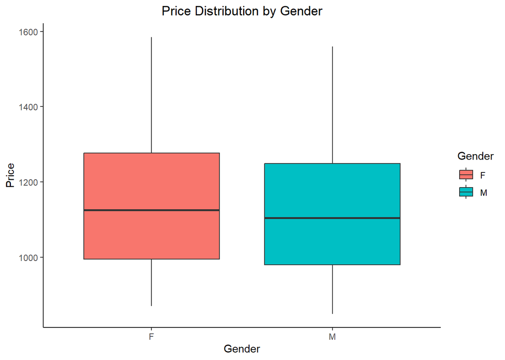

The relationship between WalkingMinutes and Price is not statistically significant, as indicated by the p-value of 0.375 for the WalkingMinutes coefficient. This means that we do not have enough evidence to conclude that there is a meaningful relationship between the distance from school and the price of the apartments in this dataset. The low R-squared value suggests that WalkingMinutes explains very little of the variation in Price.

```
## [1] 1
```

```
## [1] 5
```

```
##
## Call:
## lm(formula = Price ~ WalkingMinutes, data = Rent)
##
## Residuals:
##    Min     1Q Median     3Q    Max
## -282.8 -152.9   -6.8  138.6  443.0
##
## Coefficients:
##                Estimate Std. Error t value Pr(>|t|)
## (Intercept)    1114.371     36.782   30.30   <2e-16 ***
## WalkingMinutes    4.606      5.175    0.89    0.375
## ---
## Signif. codes:  0 '***' 0.001 '**' 0.01 '*' 0.05 '.' 0.1 ' ' 1
##
## Residual standard error: 178.2 on 105 degrees of freedom
## Multiple R-squared:  0.00749,    Adjusted R-squared:  -0.001963
## F-statistic: 0.7923 on 1 and 105 DF,  p-value: 0.3754
```

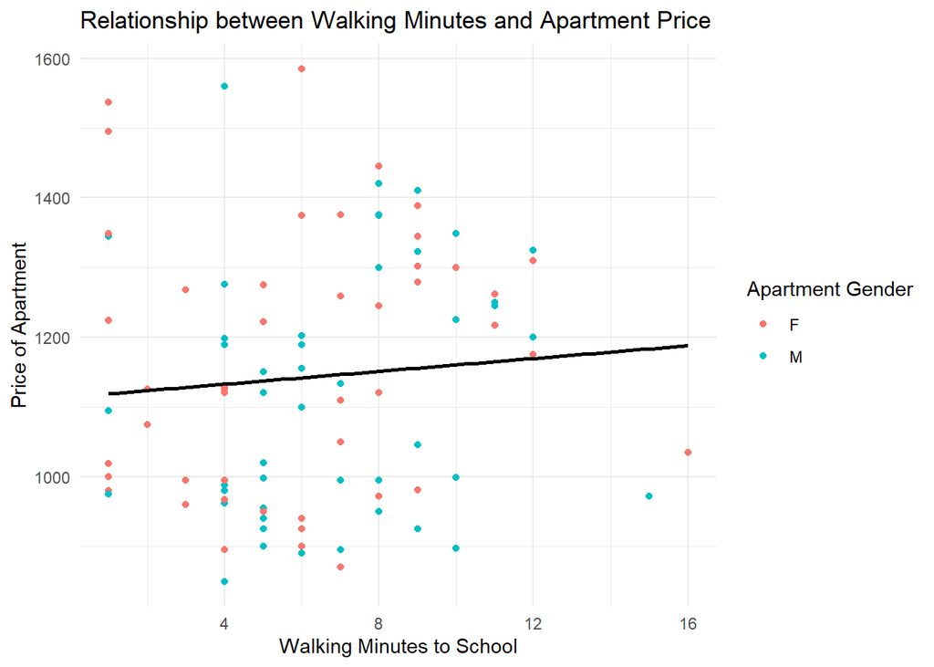

In the ‘Price Distribution by Gender’ boxplot, we examine the distribution of rental prices for student housing in the Rexburg area, categorized by gender. This visualization highlights key trends and differences in the pricing of male and female student accommodations. While the overall cost range appears similar for both genders, a noteworthy observation is that the average (mean) rent for female housing tends to be higher than that for male housing. This suggests a gender-based variation in the pricing structure of student apartments in this region.

[output not shown]

Count: This column shows the number of rent entries available for each gender. It gives an idea of the dataset’s size for male and female housing.

Mean (Average) Price: This is the average rent price for each gender. According to your paragraph, we expect to see that the mean price for female housing is higher than that for male housing, which aligns with the observation that female apartments are more expensive on average.

Median Price: The median gives the middle value of the rent prices when ordered from lowest to highest for each gender. This is less affected by outliers and extreme values than the mean and provides another perspective on the central tendency of the rent prices.

Standard Deviation (SD): This measures the spread or variability of the rent prices around the mean. A higher standard deviation would indicate a wider range of prices within that gender category.

Interquartile Range (IQR): This is the range between the first quartile (25th percentile) and the third quartile (75th percentile) and represents the middle 50% of the data. It’s a measure of the dispersion similar to standard deviation but less influenced by outliers.

Minimum (Min) and Maximum (Max) Prices: These values show the range of the rent prices, from the lowest to the highest, for each gender category.

By examining these statistics, We can gain a comprehensive understanding of how rent prices are distributed and vary between male and female student housing in Rexburg. The table will quantitatively support the trends and observations noted in the boxplot and your descriptive paragraph